# Fire Refuges Or Fire Traps?

Koala and glider sightings in fire-prone NSW and Queensland regions

## Research Question

> **Fire refuges or fire traps? Are koala and glider sighting hotspots concentrated in regions with repeated fire history?**

This asks whether regions with many records of iconic arboreal mammals are also regions with high historical fire pressure.

The analysis is deliberately framed as **spatial overlap**, not population decline. The animal file contains presence records, so a high number of sightings can reflect animal presence, observer effort, or both. It should not be interpreted as true abundance.

## Data

This first prototype combines:

- `animal_sightings.csv`: point records for koalas and gliders.
- `au_admin2_boundaries.geojson`: local government area boundaries for NSW, Queensland and Victoria.
- `fire_prone_divisions.csv`: existing fire-history summary by local government area for NSW and Queensland.

Because the fire summary covers NSW and Queensland only, the analysis is limited to those two states.

```r
library(tidyverse)
library(sf)
library(lubridate)
library(knitr)
library(scales)
library(ggrepel)

theme_set(theme_minimal(base_size = 12))

animal_path <- "animal_sightings.csv"
admin_path <- "au_admin2_boundaries.geojson"
fire_path <- "fire_prone_divisions.csv"
```

## Load And Prepare Geography

```r
admin <- st_read(admin_path, quiet = TRUE) |>
  st_transform(4326) |>
  filter(ADM1_NAME %in% c("New South Wales", "Queensland")) |>
  select(ADM1_NAME, ADM2_NAME, geometry)

admin_area <- admin |>
  st_transform(3577) |>
  mutate(lga_area_ha = as.numeric(st_area(geometry)) / 10000) |>
  st_drop_geometry() |>
  select(ADM1_NAME, ADM2_NAME, lga_area_ha)

fire_lga <- read_csv(fire_path, show_col_types = FALSE) |>
  filter(ADM1_NAME %in% c("New South Wales", "Queensland")) |>
  mutate(
    earliest_fire = as.Date(earliest_fire),
    latest_fire = as.Date(latest_fire)
  )

list(
  admin_lgas = nrow(admin),
  fire_summary_lgas = nrow(fire_lga)
) |>
  enframe(name = "metric", value = "value") |>
  kable()
```

| metric | value |
| --- | --- |
| admin_lgas | 227 |
| fire_summary_lgas | 67 |

## Load Animal Sightings

```r
animals <- read_csv(animal_path, show_col_types = FALSE) |>
  filter(
    occurrenceStatus == "PRESENT",
    !is.na(decimalLongitude),
    !is.na(decimalLatitude),
    between(decimalLongitude, 140, 156),
    between(decimalLatitude, -40, -9)
  ) |>
  mutate(
    event_date = suppressWarnings(as.Date(eventDate)),
    year = year(event_date),
    species_group = case_when(
      str_detect(scientificName, "^Phascolarctos cinereus") ~ "Koala",
      str_detect(scientificName, "^Petauroides volans") ~ "Greater glider",
      str_detect(scientificName, "^Petaurus australis") ~ "Yellow-bellied glider",
      TRUE ~ "Other"
    )
  ) |>
  filter(species_group != "Other") |>
  distinct(recordID, .keep_all = TRUE)

animals |>
  count(species_group, sort = TRUE) |>
  kable()
```

| species_group | n |
| --- | --- |
| Koala | 352948 |
| Greater glider | 45669 |
| Yellow-bellied glider | 30196 |

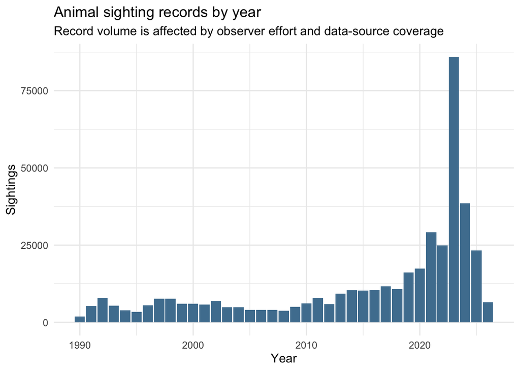

```r
animals |>
  filter(!is.na(year)) |>
  count(year) |>
  ggplot(aes(x = year, y = n)) +
  geom_col(fill = "#4f7f9f") +
  labs(
    title = "Animal sighting records by year",
    subtitle = "Record volume is affected by observer effort and data-source coverage",
    x = "Year",
    y = "Sightings"
  )
```

## Spatial Join: Sightings To LGAs

```r
animal_points <- st_as_sf(
  animals,
  coords = c("decimalLongitude", "decimalLatitude"),
  crs = 4326,
  remove = FALSE
)

animal_lga <- st_join(
  animal_points,
  admin |> select(ADM1_NAME, ADM2_NAME),
  join = st_within,
  left = FALSE
)

animal_lga_summary <- animal_lga |>
  st_drop_geometry() |>
  group_by(ADM1_NAME, ADM2_NAME) |>
  summarise(
    total_sightings = n(),
    koala_sightings = sum(species_group == "Koala"),
    greater_glider_sightings = sum(species_group == "Greater glider"),
    yellow_bellied_glider_sightings = sum(species_group == "Yellow-bellied glider"),
    target_species_groups = n_distinct(species_group),
    recent_sightings_2019_onward = sum(year >= 2019, na.rm = TRUE),
    first_sighting_year = min(year, na.rm = TRUE),
    latest_sighting_year = max(year, na.rm = TRUE),
    .groups = "drop"
  )

animal_lga_summary |>
  arrange(desc(total_sightings)) |>
  slice_head(n = 15) |>
  kable()
```

| ADM1_NAME | ADM2_NAME | total_sightings | koala_sightings | greater_glider_sightings | yellow_bellied_glider_sightings | target_species_groups | recent_sightings_2019_onward | first_sighting_year | latest_sighting_year |
| --- | --- | --- | --- | --- | --- | --- | --- | --- | --- |
| New South Wales | Wingecarribee (A) | 24282 | 23025 | 1012 | 245 | 3 | 19903 | 1990 | 2026 |
| Queensland | Redland (C) | 23962 | 23934 | 26 | 2 | 3 | 5911 | 1990 | 2026 |
| New South Wales | Great Lakes (A) | 19721 | 19059 | 400 | 262 | 3 | 14824 | 1990 | 2026 |
| New South Wales | Port Macquarie-Hastings (A) | 19717 | 18291 | 779 | 647 | 3 | 8401 | 1990 | 2026 |
| New South Wales | Clarence Valley (A) | 18231 | 11734 | 3197 | 3300 | 3 | 9208 | 1990 | 2026 |
| Queensland | Brisbane (C) | 18048 | 17976 | 69 | 3 | 3 | 12698 | 1990 | 2026 |
| New South Wales | Campbelltown (C) | 17513 | 17507 | 3 | 3 | 3 | 15737 | 1990 | 2026 |
| Queensland | Gold Coast (C) | 15261 | 15199 | 56 | 6 | 3 | 6428 | 1990 | 2026 |
| Queensland | Moreton Bay (R) | 14266 | 14190 | 75 | 1 | 3 | 1333 | 1990 | 2026 |
| New South Wales | Lismore (C) | 12775 | 12637 | 124 | 14 | 3 | 7112 | 1990 | 2026 |
| New South Wales | Bega Valley (A) | 12687 | 5894 | 2378 | 4415 | 3 | 5455 | 1990 | 2026 |
| New South Wales | Uralla (A) | 12208 | 12208 | 0 | 0 | 1 | 12044 | 1992 | 2026 |
| New South Wales | Port Stephens (A) | 11513 | 11507 | 4 | 2 | 3 | 3950 | 1990 | 2026 |
| New South Wales | Cooma-Monaro (A) | 8793 | 8269 | 505 | 19 | 3 | 7332 | 1990 | 2026 |
| New South Wales | Greater Taree (C) | 7555 | 6534 | 780 | 241 | 3 | 5581 | 1990 | 2026 |

## Combine Fire Pressure And Sighting Hotspots

```r
combined_lga <- admin |>
  st_drop_geometry() |>
  distinct(ADM1_NAME, ADM2_NAME) |>
  left_join(admin_area, by = c("ADM1_NAME", "ADM2_NAME")) |>
  left_join(fire_lga, by = c("ADM1_NAME", "ADM2_NAME")) |>
  left_join(animal_lga_summary, by = c("ADM1_NAME", "ADM2_NAME")) |>
  mutate(
    across(
      c(
        fire_count,
        total_area_ha,
        avg_area_ha_per_fire,
        total_sightings,
        koala_sightings,
        greater_glider_sightings,
        yellow_bellied_glider_sightings,
        target_species_groups,
        recent_sightings_2019_onward
      ),
      ~ replace_na(.x, 0)
    ),
    has_fire_history = fire_count > 0,
    has_target_sighting = total_sightings > 0,
    fire_count_per_1000_km2 = fire_count / (lga_area_ha / 100000),
    repeated_burn_area_ratio = total_area_ha / lga_area_ha,
    sightings_per_1000_km2 = total_sightings / (lga_area_ha / 100000)
  )

combined_lga |>
  summarise(
    lgas = n(),
    lgas_with_fire_summary = sum(has_fire_history),
    lgas_with_target_sightings = sum(has_target_sighting),
    lgas_with_both = sum(has_fire_history & has_target_sighting)
  ) |>
  kable()
```

| lgas | lgas_with_fire_summary | lgas_with_target_sightings | lgas_with_both |
| --- | --- | --- | --- |
| 227 | 67 | 174 | 66 |

The `repeated_burn_area_ratio` can exceed 1 because the fire history is cumulative: the same area can burn multiple times across decades.

```r
combined_lga |>
  filter(has_fire_history, has_target_sighting) |>
  arrange(desc(total_sightings), desc(fire_count)) |>
  select(
    ADM1_NAME,
    ADM2_NAME,
    total_sightings,
    koala_sightings,
    greater_glider_sightings,
    yellow_bellied_glider_sightings,
    fire_count,
    total_area_ha,
    latest_fire
  ) |>
  slice_head(n = 20) |>
  kable(digits = 1)
```

| ADM1_NAME | ADM2_NAME | total_sightings | koala_sightings | greater_glider_sightings | yellow_bellied_glider_sightings | fire_count | total_area_ha | latest_fire |
| --- | --- | --- | --- | --- | --- | --- | --- | --- |
| New South Wales | Wingecarribee (A) | 24282 | 23025 | 1012 | 245 | 642 | 233366.5 | 2026-05-01 |
| New South Wales | Great Lakes (A) | 19721 | 19059 | 400 | 262 | 1005 | 355410.5 | 2026-02-24 |
| New South Wales | Port Macquarie-Hastings (A) | 19717 | 18291 | 779 | 647 | 576 | 191546.6 | 2026-04-18 |
| New South Wales | Clarence Valley (A) | 18231 | 11734 | 3197 | 3300 | 2455 | 1831996.6 | 2026-04-17 |
| Queensland | Brisbane (C) | 18048 | 17976 | 69 | 3 | 313 | 125318.6 | 2026-07-15 |
| New South Wales | Bega Valley (A) | 12687 | 5894 | 2378 | 4415 | 1238 | 862163.6 | 2026-05-06 |
| New South Wales | Cooma-Monaro (A) | 8793 | 8269 | 505 | 19 | 306 | 137900.5 | 2026-04-25 |
| New South Wales | Greater Taree (C) | 7555 | 6534 | 780 | 241 | 446 | 199107.7 | 2026-05-09 |
| New South Wales | Armidale Dumaresq (A) | 7391 | 4171 | 3200 | 20 | 293 | 208157.4 | 2026-04-11 |
| New South Wales | Shoalhaven (C) | 7089 | 4504 | 1005 | 1580 | 2340 | 1094542.0 | 2026-05-10 |
| New South Wales | Hawkesbury (C) | 6931 | 6647 | 46 | 238 | 1033 | 597618.6 | 2026-05-03 |
| New South Wales | Richmond Valley (A) | 4427 | 3584 | 342 | 501 | 556 | 328023.0 | 2026-06-05 |
| Queensland | Lockyer Valley (R) | 4165 | 4123 | 41 | 1 | 233 | 152927.3 | 2026-07-14 |
| New South Wales | Walcha (A) | 4153 | 632 | 3119 | 402 | 442 | 592375.3 | 2026-04-23 |
| New South Wales | Wollondilly (A) | 3952 | 3320 | 364 | 268 | 701 | 404953.9 | 2026-04-13 |
| New South Wales | Cessnock (C) | 3514 | 2640 | 374 | 500 | 542 | 201680.2 | 2025-12-08 |
| New South Wales | Upper Hunter Shire (A) | 3386 | 2218 | 1165 | 3 | 194 | 88176.5 | 2025-12-11 |
| New South Wales | Tenterfield (A) | 3299 | 1656 | 1273 | 370 | 827 | 812024.7 | 2026-06-24 |
| New South Wales | Kempsey (A) | 3085 | 2499 | 395 | 191 | 578 | 250349.8 | 2026-03-27 |
| New South Wales | Gloucester (A) | 3003 | 1511 | 1432 | 60 | 260 | 85861.8 | 2025-10-06 |

## Classify Regions: Refuge Or Trap?

This classification is exploratory:

- **High biodiversity signal:** top quartile of target animal sightings among LGAs with at least one target sighting.
- **High fire pressure:** top quartile of fire count among LGAs with fire-history records.
- **Possible fire trap:** high biodiversity signal and high fire pressure.
- **Possible refuge:** high biodiversity signal and lower recorded fire pressure.

```r
biodiversity_threshold <- combined_lga |>
  filter(total_sightings > 0) |>
  summarise(q75 = quantile(total_sightings, 0.75, na.rm = TRUE)) |>
  pull(q75)

fire_threshold <- combined_lga |>
  filter(fire_count > 0) |>
  summarise(q75 = quantile(fire_count, 0.75, na.rm = TRUE)) |>
  pull(q75)

classified_lga <- combined_lga |>
  mutate(
    high_biodiversity_signal = total_sightings >= biodiversity_threshold,
    high_fire_pressure = fire_count >= fire_threshold,
    class = case_when(
      high_biodiversity_signal & high_fire_pressure ~ "Possible fire trap",
      high_biodiversity_signal & !high_fire_pressure ~ "Possible refuge",
      !high_biodiversity_signal & high_fire_pressure ~ "High fire / lower sightings",
      TRUE ~ "Lower fire / lower sightings"
    )
  )

tibble(
  threshold = c("High biodiversity signal", "High fire pressure"),
  rule = c(
    "Top quartile of target animal sightings among LGAs with sightings",
    "Top quartile of fire count among LGAs with fire records"
  ),
  cutoff = c(biodiversity_threshold, fire_threshold)
) |>
  kable(digits = 1)
```

| threshold | rule | cutoff |
| --- | --- | --- |
| High biodiversity signal | Top quartile of target animal sightings among LGAs with sightings | 1982.2 |
| High fire pressure | Top quartile of fire count among LGAs with fire records | 691.5 |

```r
classified_lga |>
  count(class, sort = TRUE) |>
  kable()
```

| class | n |
| --- | --- |
| Lower fire / lower sightings | 174 |
| Possible refuge | 36 |
| High fire / lower sightings | 9 |
| Possible fire trap | 8 |

## Main Visual

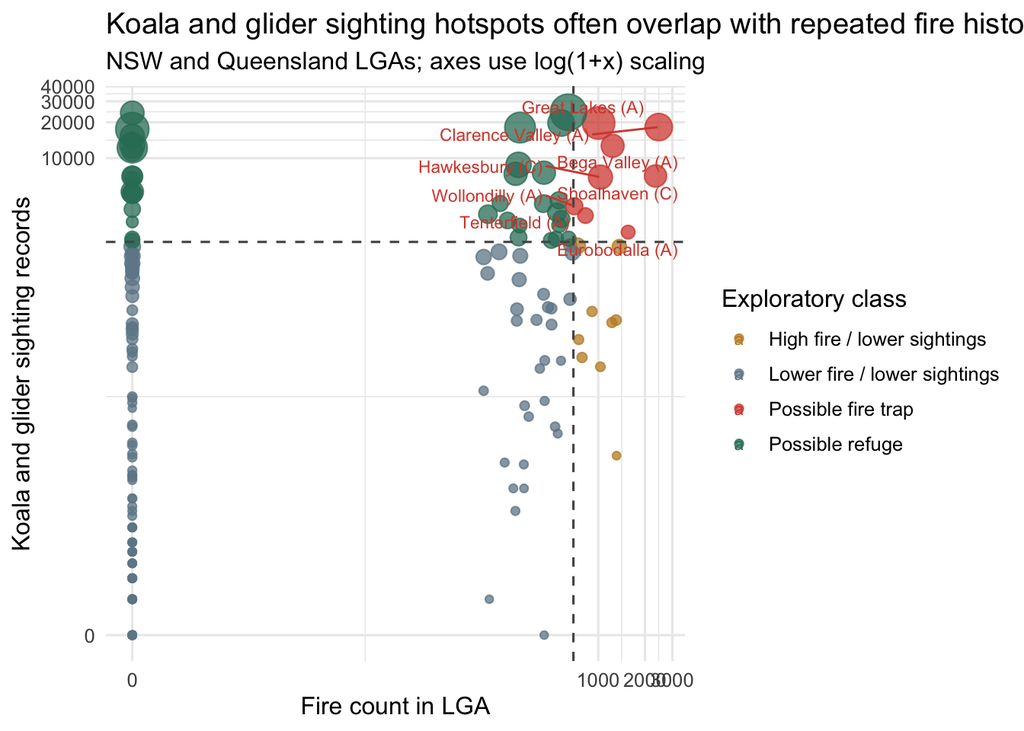

```r
plot_data <- classified_lga |>
  mutate(label = if_else(class == "Possible fire trap", ADM2_NAME, NA_character_))

ggplot(plot_data, aes(x = fire_count, y = total_sightings, color = class)) +
  geom_point(aes(size = recent_sightings_2019_onward), alpha = 0.75) +
  geom_vline(xintercept = fire_threshold, linetype = "dashed", color = "#555555") +
  geom_hline(yintercept = biodiversity_threshold, linetype = "dashed", color = "#555555") +
  ggrepel::geom_text_repel(aes(label = label), max.overlaps = 20, size = 3, na.rm = TRUE) +
  scale_x_continuous(trans = "log1p") +
  scale_y_continuous(trans = "log1p") +
  scale_color_manual(values = c(
    "Possible fire trap" = "#d64b3c",
    "Possible refuge" = "#2f7d66",
    "High fire / lower sightings" = "#c18b2b",
    "Lower fire / lower sightings" = "#6f8796"
  )) +
  scale_size_continuous(range = c(1.5, 8), guide = "none") +
  labs(
    title = "Koala and glider sighting hotspots often overlap with repeated fire history",
    subtitle = "NSW and Queensland LGAs; axes use log(1+x) scaling",
    x = "Fire count in LGA",
    y = "Koala and glider sighting records",
    color = "Exploratory class"
  )
```

## Map Of Exploratory Classes

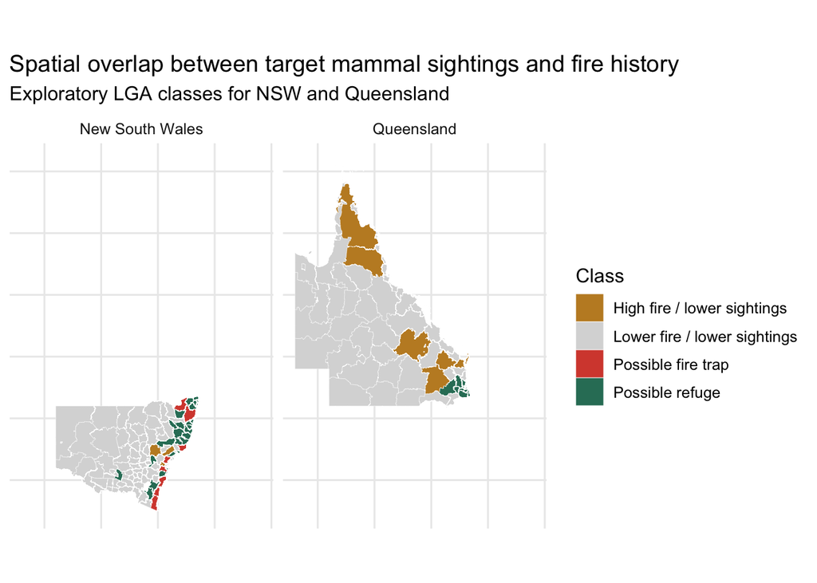

```r
map_lga <- admin |>
  left_join(
    classified_lga |>
      select(ADM1_NAME, ADM2_NAME, class, total_sightings, fire_count),
    by = c("ADM1_NAME", "ADM2_NAME")
  )

ggplot(map_lga) +
  geom_sf(aes(fill = class), color = "white", linewidth = 0.08) +
  scale_fill_manual(values = c(
    "Possible fire trap" = "#d64b3c",
    "Possible refuge" = "#2f7d66",
    "High fire / lower sightings" = "#c18b2b",
    "Lower fire / lower sightings" = "#d9d9d9"
  ), na.value = "#eeeeee") +
  facet_wrap(vars(ADM1_NAME)) +
  labs(
    title = "Spatial overlap between target mammal sightings and fire history",
    subtitle = "Exploratory LGA classes for NSW and Queensland",
    fill = "Class"
  ) +
  theme(axis.text = element_blank(), axis.title = element_blank())
```

## Statistical Checks

### Are Sighting Hotspots More Likely To Be Fire-Prone?

This uses a 2x2 Fisher exact test: high versus lower biodiversity signal crossed with high versus lower fire pressure.

```r
overlap_table <- classified_lga |>
  count(high_biodiversity_signal, high_fire_pressure) |>
  pivot_wider(names_from = high_fire_pressure, values_from = n, values_fill = 0) |>
  column_to_rownames("high_biodiversity_signal") |>
  as.matrix()

fisher_result <- fisher.test(overlap_table)

overlap_table
```

```
      FALSE TRUE
FALSE   174    9
TRUE     36    8
```

```r
tibble(
  statistic = c("odds_ratio", "p_value"),
  value = c(unname(fisher_result$estimate), fisher_result$p.value)
) |>
  kable(digits = 4)
```

| statistic | value |
| --- | --- |
| odds_ratio | 4.2587 |
| p_value | 0.0067 |

### Is Fire Count Associated With Sighting Count?

Spearman correlation is used because both variables are skewed and count-like.

```r
cor_data <- classified_lga |>
  filter(total_sightings > 0 | fire_count > 0)

spearman_test <- cor.test(
  cor_data$fire_count,
  cor_data$total_sightings,
  method = "spearman",
  exact = FALSE
)

tibble(
  statistic = c("spearman_rho", "p_value", "lgas_used"),
  value = c(unname(spearman_test$estimate), spearman_test$p.value, nrow(cor_data))
) |>
  kable(digits = 4)
```

| statistic | value |
| --- | --- |
| spearman_rho | 0.4428 |
| p_value | 0.0000 |
| lgas_used | 175.0000 |

## Candidate Priority Regions

These LGAs have both high target-mammal sighting counts and high fire counts under the top-quartile rules.

```r
classified_lga |>
  filter(class == "Possible fire trap") |>
  arrange(desc(total_sightings), desc(fire_count)) |>
  select(
    ADM1_NAME,
    ADM2_NAME,
    total_sightings,
    koala_sightings,
    greater_glider_sightings,
    yellow_bellied_glider_sightings,
    fire_count,
    total_area_ha,
    latest_fire,
    repeated_burn_area_ratio
  ) |>
  kable(digits = 2)
```

| ADM1_NAME | ADM2_NAME | total_sightings | koala_sightings | greater_glider_sightings | yellow_bellied_glider_sightings | fire_count | total_area_ha | latest_fire | repeated_burn_area_ratio |
| --- | --- | --- | --- | --- | --- | --- | --- | --- | --- |
| New South Wales | Great Lakes (A) | 19721 | 19059 | 400 | 262 | 1005 | 355410.5 | 2026-02-24 | 1.05 |
| New South Wales | Clarence Valley (A) | 18231 | 11734 | 3197 | 3300 | 2455 | 1831996.6 | 2026-04-17 | 1.76 |
| New South Wales | Bega Valley (A) | 12687 | 5894 | 2378 | 4415 | 1238 | 862163.6 | 2026-05-06 | 1.37 |
| New South Wales | Shoalhaven (C) | 7089 | 4504 | 1005 | 1580 | 2340 | 1094542.0 | 2026-05-10 | 2.42 |
| New South Wales | Hawkesbury (C) | 6931 | 6647 | 46 | 238 | 1033 | 597618.6 | 2026-05-03 | 2.15 |
| New South Wales | Wollondilly (A) | 3952 | 3320 | 364 | 268 | 701 | 404953.9 | 2026-04-13 | 1.58 |
| New South Wales | Tenterfield (A) | 3299 | 1656 | 1273 | 370 | 827 | 812024.7 | 2026-06-24 | 1.11 |
| New South Wales | Eurobodalla (A) | 2395 | 463 | 767 | 1165 | 1558 | 1057533.8 | 2026-05-12 | 3.08 |

## Interpretation

This analysis gives a concrete environmental version of “Is Australia doing well?”:

> Australia is not doing equally well everywhere if regions that act as visible koala and glider hotspots are also exposed to repeated fire history.

The useful output is not a claim that fire caused animal decline. The useful output is a **risk-prioritisation map**:

- **Possible fire traps** are places where conservation attention may be urgent because target-mammal records and fire history overlap.
- **Possible refuges** are places with many target-mammal records and lower recorded fire pressure.
- The results should be interpreted with observer-effort bias, presence-only records, and incomplete fire coverage in mind.

Best refined research question:

> **Which NSW and Queensland regions are ecological double-risk zones, combining high koala/glider sighting activity with repeated fire history?**